# GGG-201D-problem-set-2

Ethan Holleman

4/28/2021

## Problem 1

### Part A

```r
expected <- function(init_allele_freq, pop_size, delta_allele_freq){

  num_delta_alleles <- pop_size * delta_allele_freq
  num_init_alleles <- pop_size * init_allele_freq
  routes <- num_init_alleles + c(-1*num_delta_alleles, num_delta_alleles)
  routes <- unique(routes[routes >= 0])  # remove negative values since not possible
  sum(mapply(dbinom, routes, pop_size, init_allele_freq))

}
```

```r
expected_change <- function(init_allele_freq, pop_size){

  magnitudes <- seq(0, 1-init_allele_freq, 0.1)
  sum(mapply(expected, init_allele_freq, pop_size, magnitudes) * magnitudes)

}
```

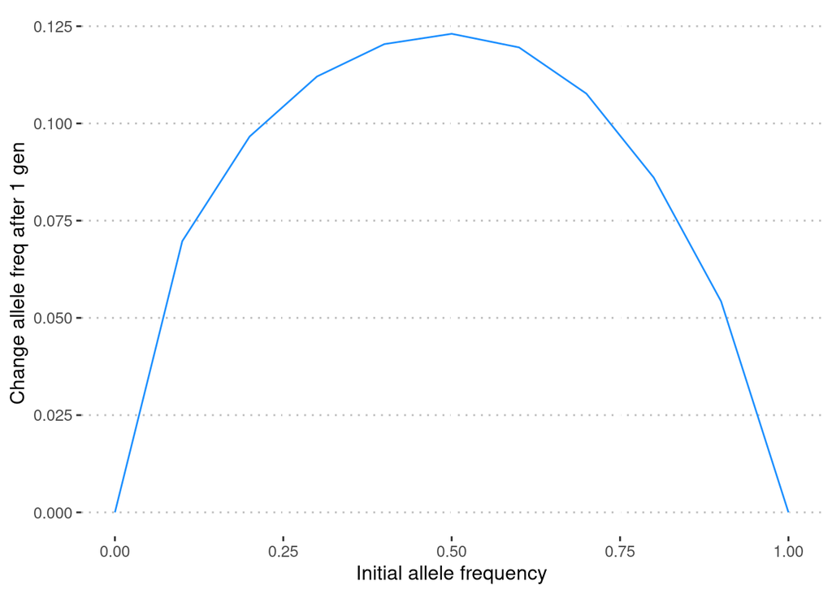

| Initial allele frequency | Pop size | Delta allele freq 1 gen |
| --- | --- | --- |
| 0.0 | 10 | 0.0000000 |
| 0.1 | 10 | 0.0697357 |
| 0.2 | 10 | 0.0966368 |
| 0.3 | 10 | 0.1120677 |
| 0.4 | 10 | 0.1203949 |
| 0.5 | 10 | 0.1230469 |
| 0.6 | 10 | 0.1195455 |
| 0.7 | 10 | 0.1076569 |
| 0.8 | 10 | 0.0860671 |
| 0.9 | 10 | 0.0542389 |
| 1.0 | 10 | 0.0000000 |

```r
library(ggplot2)
library(ggpubr)

df.a <- data.frame(init_allele_freq=seq(0, 1, 0.1), pop_size=10)
df.a$delta_allele_freq <- mapply(expected_change, df.a$init_allele_freq, df.a$pop_size)
ggplot(df.a, aes(x=init_allele_freq, y=delta_allele_freq)) + geom_line(color='dodgerblue') +
      theme_pubclean() + labs(x='Initial allele frequency', y='Change allele freq after 1 gen')
```

### Part B

Use the same program to generate a scatter plot that shows how expected allele frequency change from genetic drift depends on population size. The x-axis should be population size and range from 2N=10 to 2N=100. The y-axis should be expected change in allele frequency after one generation. Perform calculations in steps of 10 with an allele frequency of 0.5

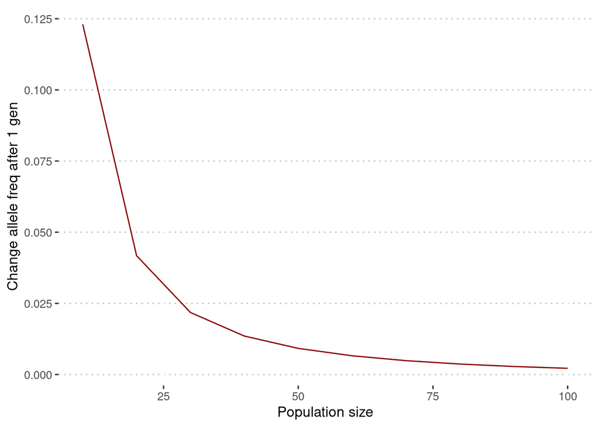

| Initial allele frequency | Pop size | Delta allele freq 1 gen |
| --- | --- | --- |
| 0.5 | 10 | 0.1230469 |
| 0.5 | 20 | 0.0417309 |
| 0.5 | 30 | 0.0217753 |
| 0.5 | 40 | 0.0135072 |
| 0.5 | 50 | 0.0091770 |
| 0.5 | 60 | 0.0065758 |
| 0.5 | 70 | 0.0048678 |
| 0.5 | 80 | 0.0036784 |
| 0.5 | 90 | 0.0028174 |
| 0.5 | 100 | 0.0021780 |

```r
df.b <- data.frame(init_allele_freq=0.5, pop_size=seq(10, 100, 10))
df.b$delta_allele_freq <- mapply(expected_change, df.b$init_allele_freq, df.b$pop_size)
ggplot(df.b, aes(x=pop_size, y=delta_allele_freq)) + geom_line(color='darkred') +
      theme_pubclean() + labs(x='Population size', y='Change allele freq after 1 gen')
```

## Question 2

You sequence a locus in three individuals from a population and obtain the below data:

```
I1:
  GCTACTTTACCATTCTCAGCGAGACGTAAGATCAGGCCAGATCCACCTCG
  GTTCCTTTAACATTCTCAGCGAGACGTAAGAGCAGGCCAGATCCACCGCC
I2:
  GCTCCTTTACCATCCTCAGCGAGACGTAAGATCAGGACAGATCCACCTCG
  GCTACTTTACCATCCTCAGCGACACGTAAGATCAGGCCAGATCCACCTCG
I3:
  GCTACTTTACCATCCTCAGCGAGACGTAAGAGCAGGCCAGATCCACCTCC
  GCTACTTTACCATCCTCAGCGAGACGTAGGAGCAGGACAGATCCACCTCG
```

### Part A

How many segregating sites (s) are present in these data?

```r
seq.df <- data.frame(
  i1.1=unlist(strsplit('GCTACTTTACCATTCTCAGCGAGACGTAAGATCAGGCCAGATCCACCTCG', '')),
  i1.2=unlist(strsplit('GTTCCTTTAACATTCTCAGCGAGACGTAAGAGCAGGCCAGATCCACCGCC', '')),
  i2.1=unlist(strsplit('GCTCCTTTACCATCCTCAGCGAGACGTAAGATCAGGACAGATCCACCTCG', '')),
  i2.2=unlist(strsplit('GCTACTTTACCATCCTCAGCGACACGTAAGATCAGGCCAGATCCACCTCG', '')),
  i3.1=unlist(strsplit('GCTACTTTACCATCCTCAGCGAGACGTAAGAGCAGGCCAGATCCACCTCC', '')),
  i3.2=unlist(strsplit('GCTACTTTACCATCCTCAGCGAGACGTAGGAGCAGGACAGATCCACCTCG', ''))
)

site_is_segregating <- function(row){

  copy1 <- length(unique(unlist(row[seq(1, length(row), 2)]))) == 1
  copy2 <- length(unique(unlist(row[seq(2, length(row), 2)]))) == 1
  if (copy1 & copy2){
    FALSE
  }else{
    TRUE
  }
}

seg_sites <- sum(apply(seq.df, 1, site_is_segregating))

message(paste('Number of segregating sites:', seg_sites))
```

```
## Number of segregating sites: 10
```

### Part B

What is pi (π) in these data?

```r
pi <- function(seq.df){

  comparisons <- combn(1:ncol(seq.df), 2)
  distances <- c()
  for (i in 1:ncol(comparisons)){
    col_a <- comparisons[1, i]
    col_b <- comparisons[2, i]
    num_diffs <- nrow(seq.df) - (sum(seq.df[, col_a] == seq.df[, col_b]))
    distances <- c(distances, num_diffs)
  }

 sum(distances) / ncol(comparisons)
}

pi_genes <- pi(seq.df)
message(paste('Pi =', pi_genes))
```

```
## Pi = 4.4
```

### Part C

What are s and π expressed in per site values?

```r
message(paste('Pi per site =', pi_genes / nrow(seq.df)))
```

```
## Pi per site = 0.088
```

```r
message(paste('Number of segregating sites per site:', seg_sites / nrow(seq.df)))
```

```
## Number of segregating sites per site: 0.2
```

### Part D

What is the minor allele frequency spectrum for these data?

```r
# number of sites with given minor allele freq, max could be 3 / 6 otherwise
# major allele
# number sites is length of seq

minor_allele_count <- function(row){

  # get number of unique alleles need to determine what major / minor allele is
  # if 1 then only 1 allele so minor allele = 09
  row.ul <- as.vector(unlist(row))
  unq.alleles <- unique(row.ul)
  if (length(unq.alleles) == 1){
    0
  }else{
    # should be length 2 if not 1
    allele.a.count <- sum(row.ul == unq.alleles[1])
    allele.b.count <- sum(row.ul == unq.alleles[2])
    # minor allele freq will be the min of these values
    min(allele.a.count, allele.b.count)
  }
}
```

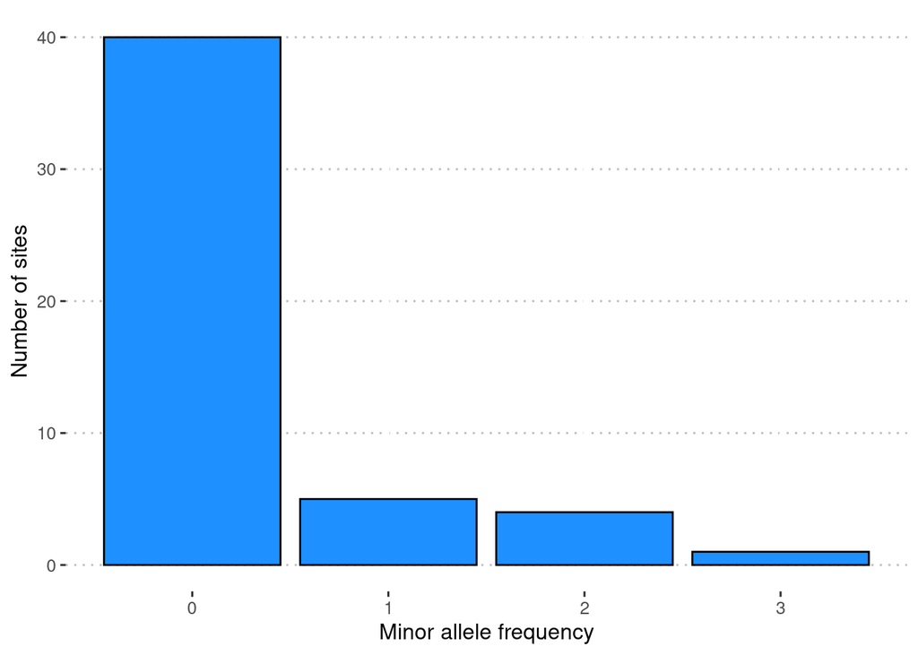

```r
seq.df.minor <- seq.df
seq.df.minor$minor <- apply(seq.df, 1, minor_allele_count)

ggplot(seq.df.minor, aes(x=minor)) + geom_bar(fill='dodgerblue', color='black') +
  theme_pubclean() + labs(x='Minor allele frequency', y='Number of sites')
```

### Part E

You next sequence the locus in a few closely related species and determine the ancestral sequence to bethe following.

```
Ancestral: GCTCCTTTACCATCCTCAGGGACACGTAAGAGCAGGCCAGACCCACCTCC
```

What is the derived allele frequency spectrum for these data?

```r
# add ancestral seq to df
ancestoral <- 'GCTCCTTTACCATCCTCAGGGACACGTAAGAGCAGGCCAGACCCACCTCC'
seq.df.anc <- seq.df
seq.df.anc$ancestor <- unlist(strsplit(ancestoral, ''))
```

```r
derived_allele_freq <- function(row){

  # assume ancestral allele is last value
  row.ul <- as.vector(unlist(row))
  ansestoral <- row[length(row)]
  sum(row[1:length(row)-1] != ansestoral)

}
```

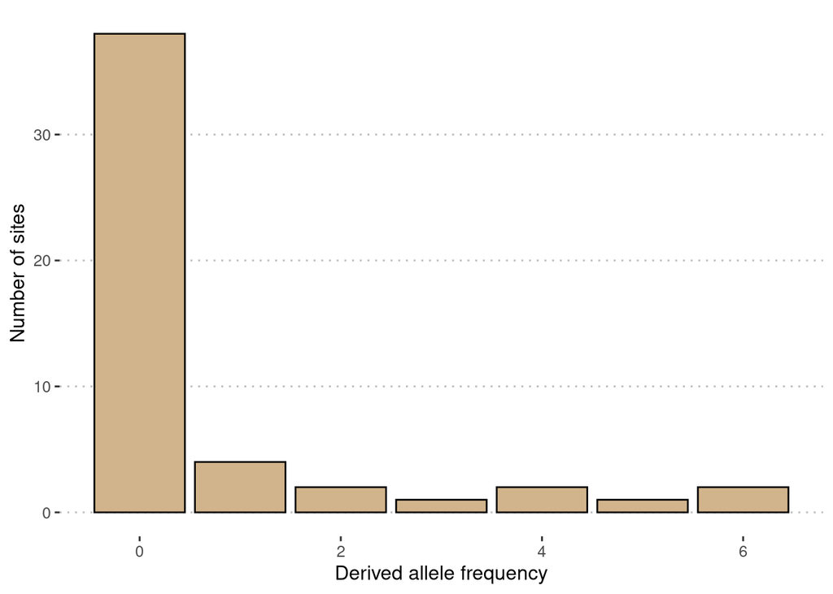

```r
derived <- apply(seq.df.anc, 1, derived_allele_freq)
ggplot(as.data.frame(derived), aes(x=derived))  + geom_bar(fill='tan', color='black') +
  theme_pubclean() + labs(x='Derived allele frequency', y='Number of sites')
```

## Question 3

Use a program such as R or Excel to generate a scatter plot that shows the properties of the coalescent process in a Wright-Fisher population. The x-axis should be number of gene copies and range from 2-50. The y-axis should be expected number of generations in N units. Perform calculations in steps of one gene copy and plot the following three expectations: (1) time to the first coalescent event; (2) time to the most recent common ancestor of all gene copies; (3) total tree length